# Statistical analysis

JH, CS

2024-02-09

# 1. Software versions

## 1.1. R version

```r
version
```

```
##                _
## platform       x86_64-w64-mingw32
## arch           x86_64
## os             mingw32
## crt            ucrt
## system         x86_64, mingw32
## status
## major          4
## minor          2.0
## year           2022
## month          04
## day            22
## svn rev        82229
## language       R
## version.string R version 4.2.0 (2022-04-22 ucrt)
## nickname       Vigorous Calisthenics
```

## 1.2. Package versions

```r
library(tidyverse)
packageVersion("tidyverse")
```

```
## [1] '2.0.0'
```

```r
library(readxl)
packageVersion("readxl")
```

```
## [1] '1.4.3'
```

```r
library(crosstable)
packageVersion("crosstable")
```

```
## [1] '0.6.2'
```

```r
library(reshape2)
packageVersion("reshape2")
```

```
## [1] '1.4.4'
```

```r
library(Hmisc)
packageVersion("Hmisc")
```

```
## [1] '5.1.1'
```

```r
library(nortest)
packageVersion("nortest")
```

```
## [1] '1.0.4'
```

```r
library(ggpubr)
packageVersion("ggpubr")
```

```
## [1] '0.6.0'
```

```r
library(rcompanion)
packageVersion("rcompanion")
```

```
## [1] '2.4.34'
```

# 2. Plot aesthetics

```r
pie_theme <- theme_minimal() +
  theme(
    axis.title.x = element_blank(),
    axis.title.y = element_blank(),
    panel.border = element_blank(),
    panel.grid=element_blank(),
    axis.ticks = element_blank(),
    plot.title=element_text(size=14, face="bold")
  ) +
  theme(axis.text.x=element_blank())

plot_theme<- theme_minimal() +
  theme(
    panel.background = element_blank(),
    panel.grid = element_blank(),
    axis.line = element_line(colour="black", linewidth=.75),
    axis.ticks = element_line(colour="black", linewidth=.75),
    axis.text = element_text(size=10, face="bold"),
    axis.title = element_text(size=12, face="bold"),
    legend.text = element_text(size=10, face="bold"),
    legend.title = element_text(size=12, face="bold")
  )
```

# 3. Data import

```r
exceldata <- read_excel("results-survey.xlsx")
Data_Tabl<- data.frame(exceldata)
```

## 3.1. Data cleaning & overview

### 3.1.1. Standardization of row names and value language

```r
colnames(Data_Tabl) <- c(
     "lastpage",
     "Image_seen_before",
     "Age",
     "Gender",
     "F15003",
     "F03004",
     "B001",
     "B003",
     "F03002",
     "B002",
     "B004",
     "F15004",
     "F03003",
     "F03001",
     "B005",
     "F15001",
     "B006",
     "F15002",
     "B007",
     "B008",
     "interviewtime",
     "grouptime_general_questions",
     "E001_time",
     "E002_time",
     "E003_time",
     "grouptime_image_classification",
     "F15003_time",
     "F03004_time",
     "B001_time",
     "B003_time",
     "F03002_time",
     "B002_time",
     "B004_time",
     "F15004_time",
     "F03003_time",
     "F03001_time",
     "B005_time",
     "F15001_time",
     "B006_time",
     "F15002_time",
     "B007_time",
     "B008_time"
     )

# translate text values to English
Data_Tabl$Image_seen_before <-
  dplyr::recode(Data_Tabl$Image_seen_before, ja="yes", nein="no")
Data_Tabl$Gender <-
  dplyr::recode(Data_Tabl$Gender, männlich="male", weiblich="female")

Data_Tabl <- Data_Tabl %>%
  dplyr::mutate(across(c(F15003,F03004,F03002,F15004,F03003,F03001,F15001,F15002,B001,B003,B002,B004,B005,B006,B007,B008), \(x) dplyr::recode(x,"KI-generiert"="AI-generated", "Echt"="genuine")))

Data_Tabl$ID <- 1:nrow(Data_Tabl)
```

### 3.1.2. Remove survey test runs

```r
# drop survey test runs
Data_Tabl <- Data_Tabl[Data_Tabl$Age != "test",]
```

### 3.1.3. Study completion

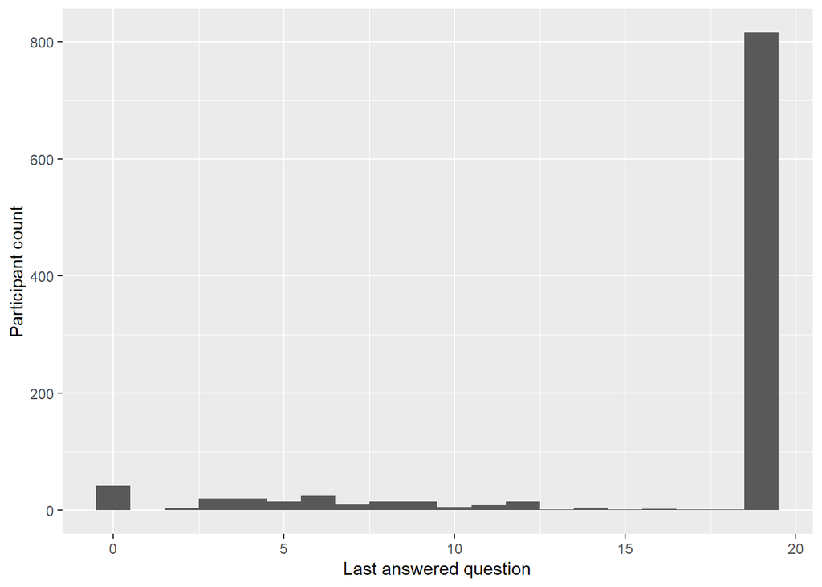

```r
# participants who just opened study without answering any question
Data_Tabl$lastpage[is.na(Data_Tabl$lastpage)] <- 0

# plot overview
histCompletion <- ggplot(Data_Tabl, aes(x=lastpage)) +
  geom_histogram(binwidth=1) +
  xlab("Last answered question") +
  ylab("Participant count")

histCompletion
```

##### Remove participants who didn’t complete the study

Number of participants starting the study

```r
n_all <- nrow(Data_Tabl)
n_all
```

```
## [1] 1021
```

Number of participants finishing the study

```r
Data_Tabl <- Data_Tabl[Data_Tabl$lastpage == 19,]
n_complete <- nrow(Data_Tabl)
n_complete
```

```
## [1] 816
```

Percent completed

```r
p_complete <- n_complete/n_all*100
p_complete
```

```
## [1] 79.92165
```

## 3.2. Demographics

##### Age

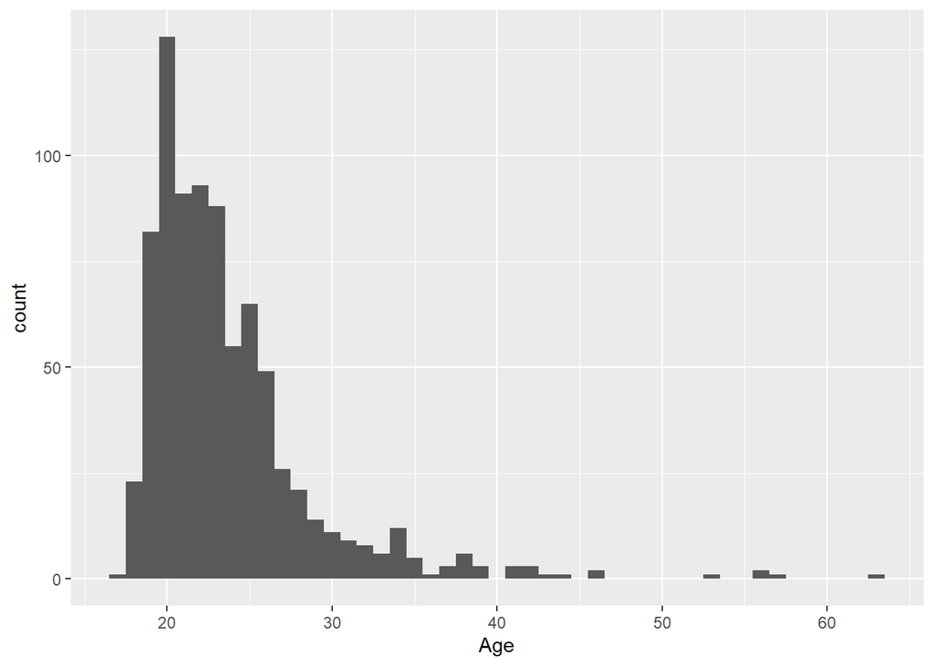

```r
# convert age to integer
Data_Tabl$Age <- Data_Tabl$Age %>% strtoi()

# mark nonsense age entries
Data_Tabl$Age[Data_Tabl$Age>110] = NA

# plot overview
histAge <- ggplot(Data_Tabl, aes(x=Age)) +
  geom_histogram(binwidth = 1)

histAge
```

##### Gender <> Prior experience

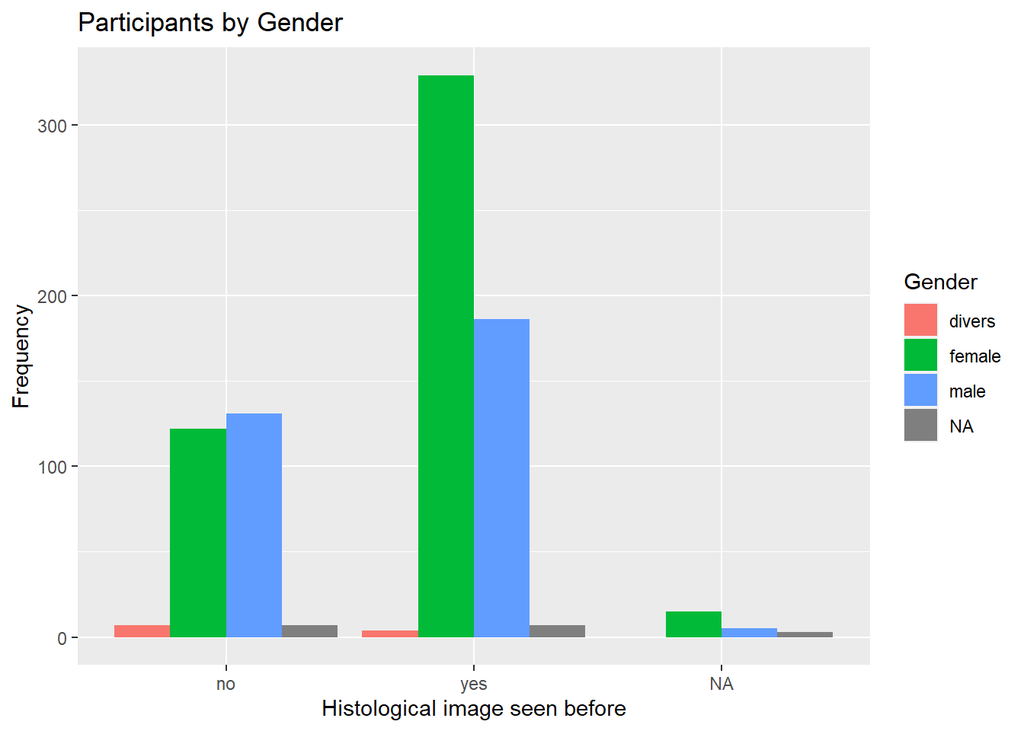

```r
gender <- as.data.frame(table(addNA(Data_Tabl$Image_seen_before),addNA(Data_Tabl$Gender)))
colnames(gender) <- c("Group", "Gender", "Frequency")


ggplot(gender, aes(x = Group, y = Frequency, fill=Gender)) +
  geom_bar(stat = "identity", position = "dodge") +
  labs(title = "Participants by Gender",
       x = "Histological image seen before",
       y = "Frequency",
       fill = "Gender")
```

##### Gender <> Prior experience

```r
crosstable(Data_Tabl, c(Image_seen_before), by=c(Gender), funs=c(sum)) %>%
  as_flextable(keep_id=TRUE)
```

| .id | label | variable | Gender divers | Gender female | Gender male | Gender NA |
| --- | --- | --- | --- | --- | --- | --- |
| Image_seen_before | Image_seen_before | no | 7 (2.69%) | 122 (46.92%) | 131 (50.38%) | 7 |
|  |  | yes | 4 (0.77%) | 329 (63.39%) | 186 (35.84%) | 7 |
|  |  | NA | 0 | 15 | 5 | 3 |

##### Age <> Prior experience

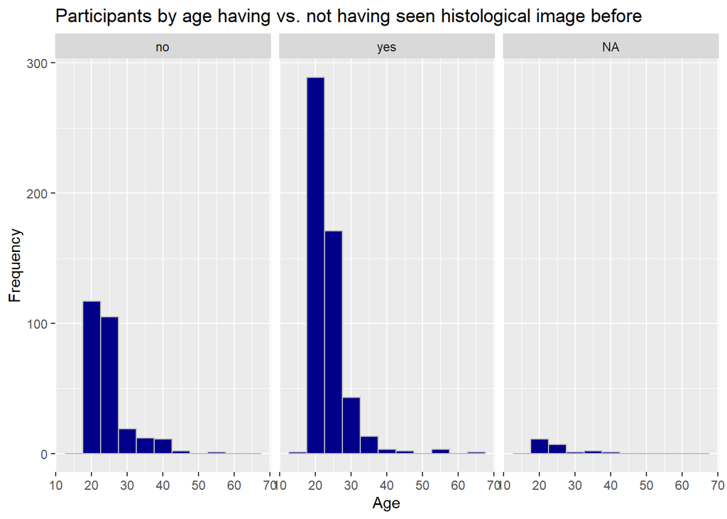

```r
ggplot(Data_Tabl, aes(x = Age), na.rm = TRUE) +
  geom_histogram(binwidth = 5, fill = "darkblue", color="grey", na.rm = TRUE) +
  facet_wrap(~ Image_seen_before) +
  labs(title = "Participants by age having vs. not having seen histological image before",
       x = "Age",
       y = "Frequency",
       fill = "Histological image seen before") +
    scale_fill_brewer(palette="Set1")
```

##### Age <> Prior experience

```r
crosstable(drop_na(Data_Tabl, Age), c(Age), by=c(Image_seen_before), funs=c(median, mean, "std dev"=sd)) %>% as_flextable(keep_id=TRUE)
```

| .id | label | variable | Image_seen_before no | Image_seen_before yes | Image_seen_before NA |
| --- | --- | --- | --- | --- | --- |
| Age | Age | median | 23.0 | 22.0 | 22.5 |
|  |  | mean | 24.5 | 23.2 | 23.9 |
|  |  | std dev | 5.5 | 5.1 | 5.4 |

##### Prior experience

```r
n_participants_experience <- table(addNA(Data_Tabl$Image_seen_before))
p_participants_experience <- n_participants_experience / length(Data_Tabl$Image_seen_before) *100

expTable <- rbind(n_participants_experience, p_participants_experience)
colnames(expTable) <- c("naive", "expert", "NaN")
rownames(expTable) <- c("count", "percent")

expTable
```

```
##             naive    expert       NaN
## count   267.00000 526.00000 23.000000
## percent  32.72059  64.46078  2.818627
```

## 3.3. Handling datasets containing missing values (‘NA’)

### 3.3.1. Missing values for classification duration

Replace duration data with NA in cases where an image has not been classified.

```r
Data_Tabl$B001_time[is.na(Data_Tabl$B001)]<-NA
Data_Tabl$B002_time[is.na(Data_Tabl$B002)]<-NA
Data_Tabl$B003_time[is.na(Data_Tabl$B003)]<-NA
Data_Tabl$B004_time[is.na(Data_Tabl$B004)]<-NA
Data_Tabl$B005_time[is.na(Data_Tabl$B005)]<-NA
Data_Tabl$B006_time[is.na(Data_Tabl$B006)]<-NA
Data_Tabl$B007_time[is.na(Data_Tabl$B007)]<-NA
Data_Tabl$B008_time[is.na(Data_Tabl$B008)]<-NA
Data_Tabl$F03001_time[is.na(Data_Tabl$F03001)]<-NA
Data_Tabl$F03002_time[is.na(Data_Tabl$F03002)]<-NA
Data_Tabl$F03003_time[is.na(Data_Tabl$F03003)]<-NA
Data_Tabl$F03004_time[is.na(Data_Tabl$F03004)]<-NA
Data_Tabl$F15001_time[is.na(Data_Tabl$F15001)]<-NA
Data_Tabl$F15002_time[is.na(Data_Tabl$F15002)]<-NA
Data_Tabl$F15003_time[is.na(Data_Tabl$F15003)]<-NA
Data_Tabl$F15004_time[is.na(Data_Tabl$F15004)]<-NA
```

### 3.3.2. Missing values for prior experience

Preparation of the analysis table: Assignment of lines answering NA to the question E001 (“Image_seen_before”).

Rationale: Those who did not know histological images are likely to even not knowing the term and, therefore might have answered NA.

```r
Data_Tabl$Image_seen_before[is.na(Data_Tabl$Image_seen_before)]<-"no"

n_participants_experience_noNA <- table(addNA(Data_Tabl$Image_seen_before))
p_participants_experience_noNA <- n_participants_experience_noNA / length(Data_Tabl$Image_seen_before)

expTable_noNA <- rbind(n_participants_experience_noNA, p_participants_experience_noNA)
colnames(expTable_noNA) <- c("naive", "expert", "nan")
rownames(expTable_noNA) <- c("n", "p")

n_naive <- expTable_noNA[1,1]
n_expert <- expTable_noNA[1,2]
expTable_noNA
```

```
##         naive      expert nan
## n 290.0000000 526.0000000   0
## p   0.3553922   0.6446078   0
```

### 3.3.3. Missing values for classifications

Skipped answers during classification are considered “misclassified”, i.e. * for artificial images ‘genuine’ replaces ‘NA’ * for genuine images ‘AI-generated’ replaces ‘NA’

##### Percent of non-classified images (i.e. skipped images in survey)

```r
na_entries_count <- sum(is.na(Data_Tabl$B001)) +
                    sum(is.na(Data_Tabl$B002)) +
                    sum(is.na(Data_Tabl$B003)) +
                    sum(is.na(Data_Tabl$B004)) +
                    sum(is.na(Data_Tabl$B005)) +
                    sum(is.na(Data_Tabl$B006)) +
                    sum(is.na(Data_Tabl$B007)) +
                    sum(is.na(Data_Tabl$B008)) +
                    sum(is.na(Data_Tabl$F03001)) +
                    sum(is.na(Data_Tabl$F03002)) +
                    sum(is.na(Data_Tabl$F03003)) +
                    sum(is.na(Data_Tabl$F03004)) +
                    sum(is.na(Data_Tabl$F15001)) +
                    sum(is.na(Data_Tabl$F15002)) +
                    sum(is.na(Data_Tabl$F15003)) +
                    sum(is.na(Data_Tabl$F15004))

entries_total <- nrow(Data_Tabl)*16
percent_na <- na_entries_count/entries_total*100
percent_na
```

```
## [1] 1.66973
```

##### Relabel non-classified images as misclassified

```r
Data_Tabl <- Data_Tabl %>%
  mutate_at(vars(F15003,F03004,F03002,F15004,F03003,F03001,F15001,F15002), ~ifelse(is.na(.), "genuine", .))

Data_Tabl <- Data_Tabl %>%
  mutate_at(vars(B001,B003,B002,B004,B005,B006,B007,B008), ~ifelse(is.na(.), "AI-generated", .))
```

##### Re-calculate age after treatment of missing values

```r
crosstable(drop_na(Data_Tabl, Age), c(Age), by=c(Image_seen_before), funs=c(median, mean, "std dev"=sd)) %>% as_flextable(keep_id=TRUE)
```

| .id | label | variable | Image_seen_before no | Image_seen_before yes |
| --- | --- | --- | --- | --- |
| Age | Age | median | 23.0 | 22.0 |
|  |  | mean | 24.5 | 23.2 |
|  |  | std dev | 5.5 | 5.1 |

### 3.3.4. Missing values for gender

Replacing ‘NA’ entries in the gender column with ‘unknown’

```r
Data_Tabl$Gender[is.na(Data_Tabl$Gender)]<-"unknown"
```

## 3.4. Format data

##### melt()

```r
classificationLong_response <- melt(Data_Tabl[,c(2:20, 43)], id = c("ID", "Image_seen_before", "Age", "Gender"))
classificationLong_time <- melt(Data_Tabl[,c(2:4, 27:43)], id = c("ID", "Image_seen_before", "Age", "Gender"))
imageClassificationDataLong <- cbind(classificationLong_response, classificationLong_time$value)
colnames(imageClassificationDataLong)[7] <- "time"
```

##### Add columns: generation, trainingBase, response, stimNo

```r
# generation: ground truth identity: artificial vs. genuine
imageClassificationDataLong$variable <- as.character(imageClassificationDataLong$variable)
imageClassificationDataLong <- imageClassificationDataLong %>%
  mutate(
    generation = case_when(
      startsWith(variable,"F") ~ "AI-generated",
      startsWith(variable,"B") ~ "genuine"
    )
  )

# trainingBase: ground truth identity: genuine (B0), trained using 3 (F3), trained using 15 F(15) genuine samples
imageClassificationDataLong <- imageClassificationDataLong %>%
  mutate(
    trainingBase = case_when(
      startsWith(variable,"F15") ~ "F15",
      startsWith(variable,"F03") ~ "F3",
      startsWith(variable,"B") ~ "B0"
    )
  )

# response: correct vs. incorrect classification
imageClassificationDataLong <- imageClassificationDataLong %>%
  mutate(
    response = case_when(
      value == generation ~ "correct",
      value != generation ~ "incorrect"
    )
  )

# response_i: same as response, but as integer
imageClassificationDataLong <- imageClassificationDataLong %>%
  mutate(
    response_i = case_when(
      value == generation ~ 1,
      value != generation ~ 0
    )
  )

# stimNo: number of stimulus in presentation during study
imageClassificationDataLong <- imageClassificationDataLong %>%
  mutate(
    stimNo = case_when(
      variable == "F15003" ~ 1,
      variable == "F03004" ~ 2,
      variable == "B001" ~ 3,
      variable == "B003" ~4,
      variable == "F03002" ~ 5,
      variable == "B002" ~ 6,
      variable == "B004" ~ 7,
      variable == "F15004" ~ 8,
      variable == "F03003" ~ 9,
      variable == "F03001" ~ 10,
      variable == "B005" ~ 11,
      variable == "F15001" ~ 12,
      variable == "B006" ~ 13,
      variable == "F15002" ~ 14,
      variable == "B007" ~ 15,
      variable == "B008" ~ 16
    )
  )
```

# 4. Analysis of classification performance

## 4.1. Analysis of the distinguishability of artificial vs. genuine images

Guiding question: Can the real images be well distinguished from the generated ones?

### 4.1.1. Format data

```r
tbl_a = table(imageClassificationDataLong[,c("generation","value")])
tbl_a <- addmargins(tbl_a)
tbl_a
```

```
##               value
## generation     AI-generated genuine   Sum
##   AI-generated         4206    2322  6528
##   genuine              2370    4158  6528
##   Sum                  6576    6480 13056
```

### 4.1.2. F1 Score

```r
TP <- tbl_a["AI-generated", "AI-generated"]
FN <- tbl_a["AI-generated", "genuine"]
FP <- tbl_a["genuine", "AI-generated"]
TN <- tbl_a["genuine", "genuine"]

precision <- TP/(TP+FP)
sens <- TP/(TP+FN)

F1_score <- 2/(1/precision + 1/sens)
F1_score
```

```
## [1] 0.6419414
```

## 4.2. Confidence intervals

### 4.2.1. Naive participants

```r
# gather data for naives
dat_unexperienced <- filter(imageClassificationDataLong,Image_seen_before=="no")

tbl_SensSpec_n = table(dat_unexperienced[,c("generation","value")])
tbl_SensSpec_n <- addmargins(tbl_SensSpec_n)

TP_n <- tbl_SensSpec_n["AI-generated", "AI-generated"]
FN_n <- tbl_SensSpec_n["AI-generated", "genuine"]
FP_n <- tbl_SensSpec_n["genuine", "AI-generated"]
TN_n <- tbl_SensSpec_n["genuine", "genuine"]


# Sensitivity + specificity: Confidence intervals  using the Wilson Score Interval.
allpos <- TP_n + FN_n
allneg <- TN_n + FP_n

sensitivity_ci_n <- binconf(TP_n,allpos,method="wilson")
specificity_ci_n <- binconf(TN_n,allneg,method="wilson")
```

```r
tbl_SensSpec_n
```

```
##               value
## generation     AI-generated genuine  Sum
##   AI-generated         1286    1034 2320
##   genuine              1075    1245 2320
##   Sum                  2361    2279 4640
```

```r
print("Sensitivity Confidence Interval:")
```

```
## [1] "Sensitivity Confidence Interval:"
```

```r
print(sensitivity_ci_n)
```

```
##   PointEst     Lower     Upper
##  0.5543103 0.5340117 0.5744294
```

```r
print("Specificity Confidence Interval:")
```

```
## [1] "Specificity Confidence Interval:"
```

```r
print(specificity_ci_n)
```

```
##   PointEst    Lower     Upper
##  0.5366379 0.516303 0.5568518
```

### 4.2.2. Expert participants

```r
# gather data for expert participants
dat_unexperienced <- filter(imageClassificationDataLong,Image_seen_before=="yes")

tbl_SensSpec_e = table(dat_unexperienced[,c("generation","value")])
tbl_SensSpec_e <- addmargins(tbl_SensSpec_e)

TP_e <- tbl_SensSpec_e["AI-generated", "AI-generated"]
FN_e <- tbl_SensSpec_e["AI-generated", "genuine"]
FP_e <- tbl_SensSpec_e["genuine", "AI-generated"]
TN_e <- tbl_SensSpec_e["genuine", "genuine"]


# Sensitivity + specificity: Confidence intervals  using the Wilson Score Interval.
allpos_e <- TP_e + FN_e
allneg_e <- TN_e + FP_e

sensitivity_ci_e <- binconf(TP_e,allpos_e,method="wilson")
specificity_ci_e <- binconf(TN_e,allneg_e,method="wilson")
```

```r
tbl_SensSpec_e
```

```
##               value
## generation     AI-generated genuine  Sum
##   AI-generated         2920    1288 4208
##   genuine              1295    2913 4208
##   Sum                  4215    4201 8416
```

```r
print("Sensitivity Confidence Interval:")
```

```
## [1] "Sensitivity Confidence Interval:"
```

```r
print(sensitivity_ci_e)
```

```
##   PointEst     Lower     Upper
##  0.6939163 0.6798201 0.7076589
```

```r
print("Specificity Confidence Interval:")
```

```
## [1] "Specificity Confidence Interval:"
```

```r
print(specificity_ci_e)
```

```
##   PointEst     Lower     Upper
##  0.6922529 0.6781371 0.7060179
```

### 4.2.3. Plot results

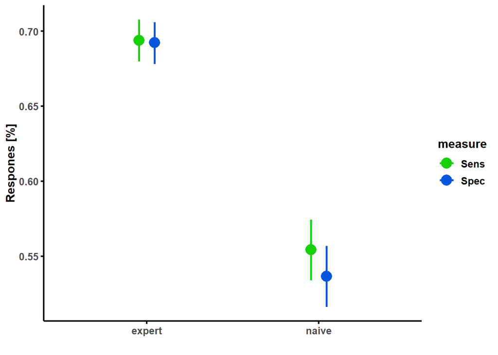

```r
df_sensSpec <- data.frame(
  subject = c("naive",
              "naive",
              "expert",
              "expert"),
  measure = c("Sens",
              "Spec",
              "Sens",
              "Spec"),
  estimate = c(sensitivity_ci_n[1],
               specificity_ci_n[1],
               sensitivity_ci_e[1],
               specificity_ci_e[1]),
  CI_lower = c(sensitivity_ci_n[2],
               specificity_ci_n[2],
               sensitivity_ci_e[2],
               specificity_ci_e[2]),
  CI_upper = c(sensitivity_ci_n[3],
               specificity_ci_n[3],
               sensitivity_ci_e[3],
               specificity_ci_e[3])
  )

ggplot(df_sensSpec, aes(x=subject, y=estimate, colour=measure, fill=measure)) +
  geom_point(position=position_dodge(0.185), size=5, shape=16) +
  geom_errorbar(aes(ymin = CI_lower, ymax = CI_upper), width=0, size=1, position=position_dodge(0.185)) +
  scale_color_manual(values =  c("#16d108", "#0756de")) +
  labs(y= "Respones [%]", x = "") +
  plot_theme
```

## 4.3. Overall performance

### 4.3.1. Naive participants

##### Numbers

```r
n_correct <- TP_n+TN_n
n_correct
```

```
## [1] 2531
```

```r
n_incorrect <- FP_n+FN_n
n_incorrect
```

```
## [1] 2109
```

```r
p_correct <- (TP_n+TN_n) / (TP_n+TN_n+FP_n+FN_n) *100
p_correct
```

```
## [1] 54.54741
```

```r
p_incorrect <- (FP_n+FN_n) / (TP_n+TN_n+FP_n+FN_n) *100
p_incorrect
```

```
## [1] 45.45259
```

##### Pie chart proportions

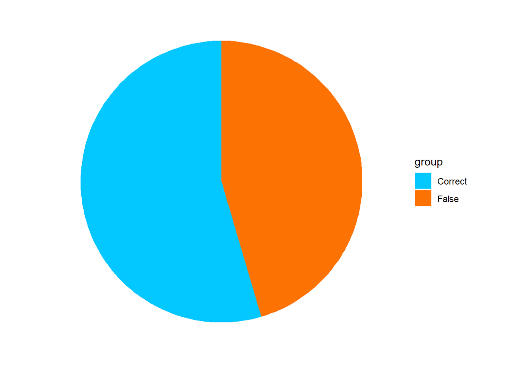

```r
# pie chart
df_n_all <- data.frame(
  group = c("Correct", "False"),
  value = c(TP_n+TN_n, FP_n+FN_n)
)

df_n_all$value <- df_n_all$value / sum(df_n_all$value) * 100

bp_n_all <- ggplot(df_n_all, aes(x="", y=value, fill=group)) +
  geom_bar(width=1, stat="identity") +
  coord_polar("y", start=0) +
  pie_theme +
  scale_fill_manual(values = c("#03c7ff", "#fc7303"))

bp_n_all
```

##### Statistics vs. chance

Binomial exact test: Performance significantly better than chance

```r
binom_n <- binom.test(TP_n+TN_n, TP_n+TN_n+FP_n+FN_n, p = 0.5,
                       alternative = c("two.sided", "less", "greater"),
                       conf.level = 0.95)

binom_n
```

```
##
##  Exact binomial test
##
## data:  TP_n + TN_n and TP_n + TN_n + FP_n + FN_n
## number of successes = 2531, number of trials = 4640, p-value = 6.225e-10
## alternative hypothesis: true probability of success is not equal to 0.5
## 95 percent confidence interval:
##  0.5310145 0.5598765
## sample estimates:
## probability of success
##              0.5454741
```

##### Performance genuine vs. artificial

Performance naive - genuine:

```r
n_correct <- TN_n
n_correct
```

```
## [1] 1245
```

```r
n_incorrect <- FP_n
n_incorrect
```

```
## [1] 1075
```

```r
p_correct <- (TN_n) / (TN_n+FP_n) *100
p_correct
```

```
## [1] 53.66379
```

```r
p_incorrect <- (FP_n) / (FP_n+TN_n) *100
p_incorrect
```

```
## [1] 46.33621
```

Performance naive - artificial:

```r
n_correct <- TP_n
n_correct
```

```
## [1] 1286
```

```r
n_incorrect <- FN_n
n_incorrect
```

```
## [1] 1034
```

```r
p_correct <- (TP_n) / (TP_n+FN_n) *100
p_correct
```

```
## [1] 55.43103
```

```r
p_incorrect <- (FN_n) / (TP_n+FN_n) *100
p_incorrect
```

```
## [1] 44.56897
```

Chi2 test: No statistical difference for performance of naive participants between image categories.

```r
correct_n <- c(TP_n, TN_n)
incorrect_n <- c(FP_n, FN_n)

cnttab_n <- matrix(c(correct_n, incorrect_n), ncol=2)
rownames(cnttab_n) <- c("Artificial", "Genuine")
colnames(cnttab_n) <- c("Correct", "False")
chi2_n <- chisq.test(cnttab_n)
print(cnttab_n)
```

```
##            Correct False
## Artificial    1286  1075
## Genuine       1245  1034
```

```r
print(chi2_n)
```

```
##
##  Pearson's Chi-squared test with Yates' continuity correction
##
## data:  cnttab_n
## X-squared = 0.0064752, df = 1, p-value = 0.9359
```

### 4.3.2. Expert participants

##### Numbers

```r
n_correct <- TP_e+TN_e
n_correct
```

```
## [1] 5833
```

```r
n_incorrect <- FP_e+FN_e
n_incorrect
```

```
## [1] 2583
```

```r
p_correct <- (TP_e+TN_e) / (TP_e+TN_e+FP_e+FN_e) *100
p_correct
```

```
## [1] 69.30846
```

```r
p_incorrect <- (FP_e+FN_e) / (TP_e+TN_e+FP_e+FN_e) *100
p_incorrect
```

```
## [1] 30.69154
```

##### Pie chart proportions

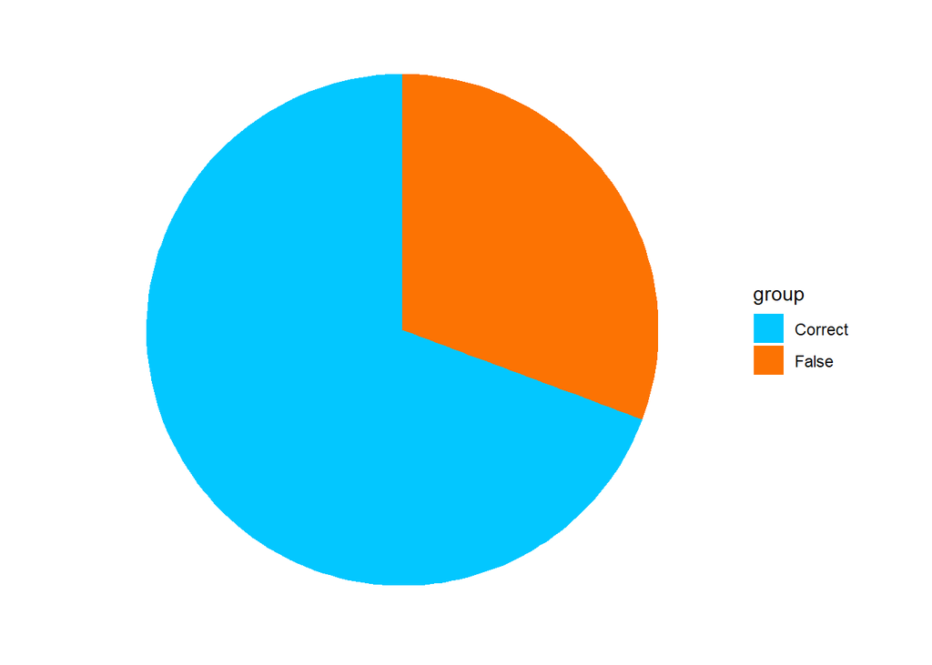

```r
df_e_all <- data.frame(
  group = c("Correct", "False"),
  value = c(TP_e+TN_e, FP_e+FN_e)
)

df_e_all$value <- df_e_all$value / sum(df_e_all$value) * 100

bp_e_all <- ggplot(df_e_all, aes(x="", y=value, fill=group)) +
  geom_bar(width=1, stat="identity") +
  coord_polar("y", start=0) +
  pie_theme +
  scale_fill_manual(values = c("#03c7ff", "#fc7303"))

bp_e_all
```

##### Statistics vs. naive participants

Experts perform statistically significantly better than naive participants.

```r
exprcd <- c((TP_e+TN_e),(FN_e+FP_e))
unexprcd <- c((TP_n+TN_n),(FN_n+FP_n))

cnttab <- matrix(c(exprcd,unexprcd), nrow = 2)
rownames(cnttab) <- c("Experienced", "Unexperienced")
colnames(cnttab) <- c("Correct", "Incorrect")

chi_quadrat_test <- chisq.test(cnttab)

print(cnttab)
```

```
##               Correct Incorrect
## Experienced      5833      2531
## Unexperienced    2583      2109
```

```r
print(chi_quadrat_test)
```

```
##
##  Pearson's Chi-squared test with Yates' continuity correction
##
## data:  cnttab
## X-squared = 282.43, df = 1, p-value < 2.2e-16
```

##### Performance genuine vs. artificial

Performance expert - genuine:

```r
n_correct <- TN_e
n_correct
```

```
## [1] 2913
```

```r
n_incorrect <- FP_e
n_incorrect
```

```
## [1] 1295
```

```r
p_correct <- (TN_e) / (TN_e+FP_e) *100
p_correct
```

```
## [1] 69.22529
```

```r
p_incorrect <- (FP_e) / (FP_e+TN_e) *100
p_incorrect
```

```
## [1] 30.77471
```

Performance expert - artificial:

```r
n_correct <- TP_e
n_correct
```

```
## [1] 2920
```

```r
n_incorrect <- FN_e
n_incorrect
```

```
## [1] 1288
```

```r
p_correct <- (TP_e) / (TP_e+FN_e) *100
p_correct
```

```
## [1] 69.39163
```

```r
p_incorrect <- (FN_e) / (TP_e+FN_e) *100
p_incorrect
```

```
## [1] 30.60837
```

Chi2 test: No statistical difference for performance of expert participants between image categories.

```r
correct_e <- c(TP_e, TN_e)
incorrect_e <- c(FP_e, FN_e)

cnttab_e <- matrix(c(correct_e, incorrect_e), ncol=2)
rownames(cnttab_e) <- c("Artificial", "Genuine")
colnames(cnttab_e) <- c("Correct", "False")
chi2_e <- chisq.test(cnttab_e)
print(cnttab_e)
```

```
##            Correct False
## Artificial    2920  1295
## Genuine       2913  1288
```

```r
print(chi2_e)
```

```
##
##  Pearson's Chi-squared test with Yates' continuity correction
##
## data:  cnttab_e
## X-squared = 0.0016204, df = 1, p-value = 0.9679
```

## 4.4. Performance by image category

### 4.4.1. Bar plot proportions

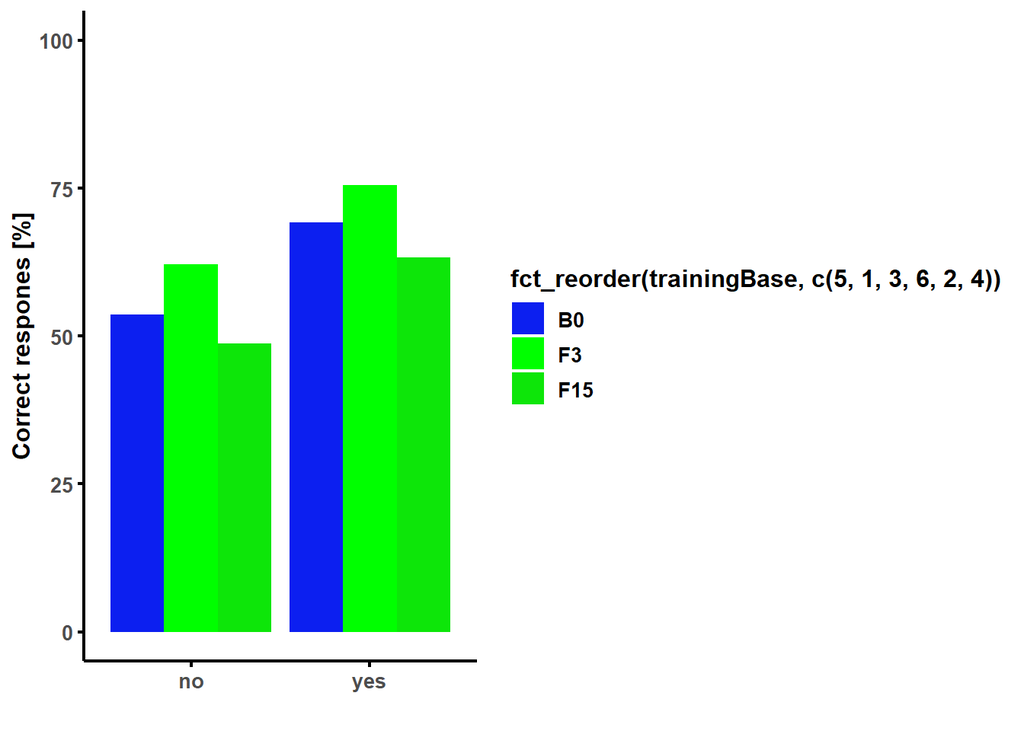

```r
imageDataCast <- dcast(imageClassificationDataLong, trainingBase + Image_seen_before ~ response, length)
imageDataCast$pCorrect <- imageDataCast$correct / (imageDataCast$correct + imageDataCast$incorrect)

bp_sup <- ggplot(imageDataCast, aes(x=Image_seen_before, y=pCorrect*100, fill=fct_reorder(trainingBase, c(5,1,3,6,2,4)))) +
  geom_bar(width=0.9, stat="identity", position="dodge") +
    scale_fill_manual(values = c("#0c1ff0", "#00ff00", "#0de609")) +
  labs(y= "Correct respones [%]", x = "") +
  ylim(0, 100) +
  plot_theme

bp_sup
```

### 4.4.2. Statistics: Binomial regression

##### Model

```r
model <- glm(factor(response_i) ~ Image_seen_before * trainingBase,
            data=imageClassificationDataLong,
            family="binomial")
summary(model)
```

```
##
## Call:
## glm(formula = factor(response_i) ~ Image_seen_before * trainingBase,
##     family = "binomial", data = imageClassificationDataLong)
##
## Deviance Residuals:
##     Min       1Q   Median       3Q      Max
## -1.6778  -1.2404   0.8577   0.9570   1.1995
##
## Coefficients:
##                                      Estimate Std. Error z value Pr(>|z|)
## (Intercept)                           0.14681    0.04163   3.526 0.000421 ***
## Image_seen_beforeyes                  0.66386    0.05338  12.438  < 2e-16 ***
## trainingBaseF15                      -0.19855    0.07200  -2.758 0.005822 **
## trainingBaseF3                        0.34932    0.07347   4.754 1.99e-06 ***
## Image_seen_beforeyes:trainingBaseF15 -0.06872    0.09135  -0.752 0.451909
## Image_seen_beforeyes:trainingBaseF3  -0.03330    0.09531  -0.349 0.726778
## ---
## Signif. codes:  0 '***' 0.001 '**' 0.01 '*' 0.05 '.' 0.1 ' ' 1
##
## (Dispersion parameter for binomial family taken to be 1)
##
##     Null deviance: 17053  on 13055  degrees of freedom
## Residual deviance: 16654  on 13050  degrees of freedom
## AIC: 16666
##
## Number of Fisher Scoring iterations: 4
```

##### Estimate + confidence intervals

```r
as.data.frame(cbind(coef(model), confint(model)))
```

```
##                                               V1       2.5 %      97.5 %
## (Intercept)                           0.14681487  0.06528249  0.22851017
## Image_seen_beforeyes                  0.66385791  0.55929463  0.76853741
## trainingBaseF15                      -0.19855054 -0.33975323 -0.05747851
## trainingBaseF3                        0.34932486  0.20565864  0.49371493
## Image_seen_beforeyes:trainingBaseF15 -0.06871547 -0.24767768  0.11042485
## Image_seen_beforeyes:trainingBaseF3  -0.03330437 -0.22014558  0.15351563
```

##### Odds ratio + confidence intervals

```r
OR_vals <- as.data.frame(exp(cbind(coef(model), confint(model))))
OR_vals
```

```
##                                             V1     2.5 %    97.5 %
## (Intercept)                          1.1581395 1.0674605 1.2567263
## Image_seen_beforeyes                 1.9422710 1.7494381 2.1566097
## trainingBaseF15                      0.8199183 0.7119460 0.9441422
## trainingBaseF3                       1.4181098 1.2283338 1.6383914
## Image_seen_beforeyes:trainingBaseF15 0.9335923 0.7806115 1.1167524
## Image_seen_beforeyes:trainingBaseF3  0.9672441 0.8024020 1.1659260
```

##### Plot results

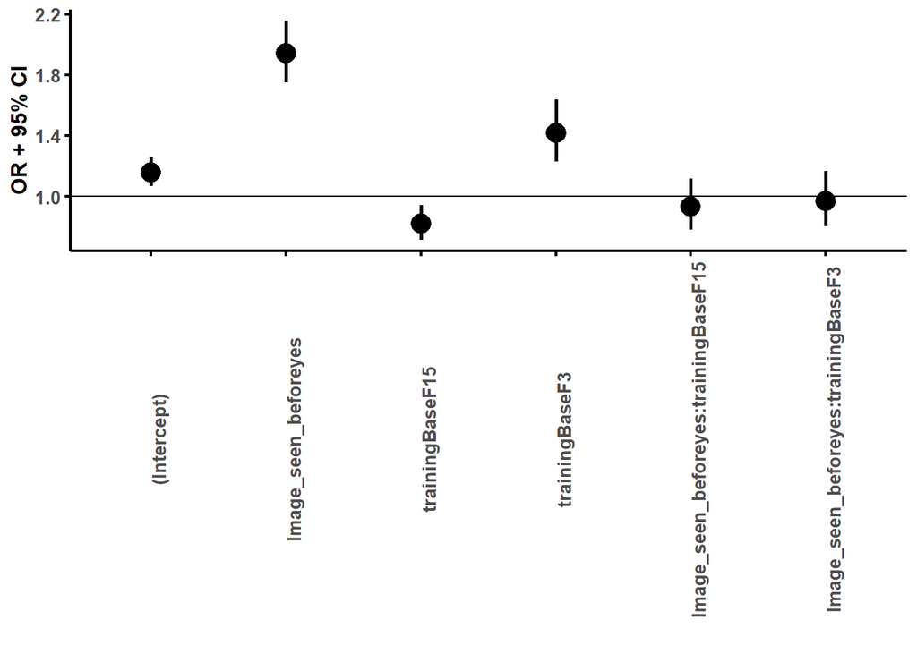

```r
OR_vals$no <- c(1:6)
colnames(OR_vals) <- c("pnt", "lower", "upper", "no")

ggplot(OR_vals, aes(y=pnt, x=factor(no))) +
  geom_point(position=position_dodge(0.185), size=5, shape=16) +
  geom_errorbar(aes(ymin = lower, ymax = upper), width=0, size=1, position=position_dodge(0.185)) +
  labs(y= "OR + 95% CI", x = "") +
  scale_x_discrete(labels=c(rownames(OR_vals))) +
  plot_theme +
  theme(axis.text.x = element_text(angle=90)) +
  geom_hline(yintercept=1)
```

## 4.5. Participant-wise performance

##### Remove images without response

```r
nrow(imageClassificationDataLong)
```

```
## [1] 13056
```

```r
imageClassificationDataLong_2 <- imageClassificationDataLong %>% drop_na(time)
nrow(imageClassificationDataLong_2)
```

```
## [1] 12838
```

### 4.5.1. Format data

```r
# preallocate
paticipant_data_length <- length(unique(imageClassificationDataLong_2$ID))
participant_data <- data.frame(no=rep(NA,paticipant_data_length),
                               id=rep(NA,paticipant_data_length),
                               experience=rep(NA,paticipant_data_length),
                               mean_response=rep(NA,paticipant_data_length))


counter = 1
for(x in unique(imageClassificationDataLong_2$ID)){
      tmp_data <- imageClassificationDataLong_2 %>% subset(ID == x)
      participant_data$no[counter] <- counter
      participant_data$id[counter] <- tmp_data$ID[1]
      participant_data$experience[counter] <- tmp_data$Image_seen_before[1]
      participant_data$mean_response[counter] <- mean(tmp_data$response_i)
      counter = counter + 1
}
```

### 4.5.2. Plot results as cumulative plot

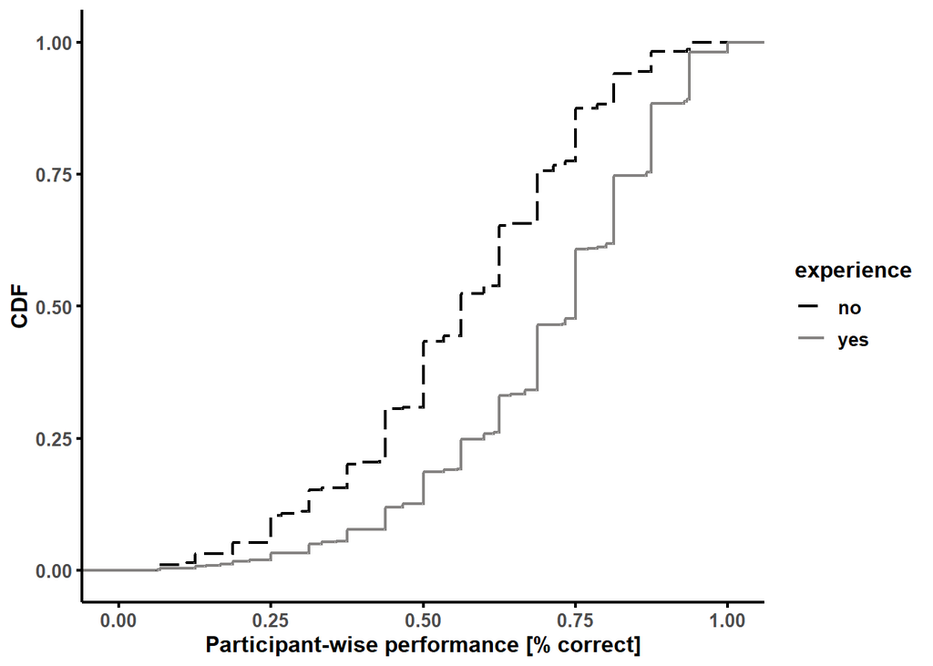

```r
ggplot(participant_data, aes(linetype=experience, color=experience, x=mean_response)) +
  stat_ecdf(size=0.75) +
  plot_theme +
  xlab("Participant-wise performance [% correct]") +
  scale_linetype_manual(values=c("longdash", "solid"))+
  scale_color_manual(values=c("black", "#858382")) +
  ylab("CDF") +
  ylim(-0.01, 1.01) + xlim(-0.01, 1.01)
```

### 4.5.3. Plot results as boxplot

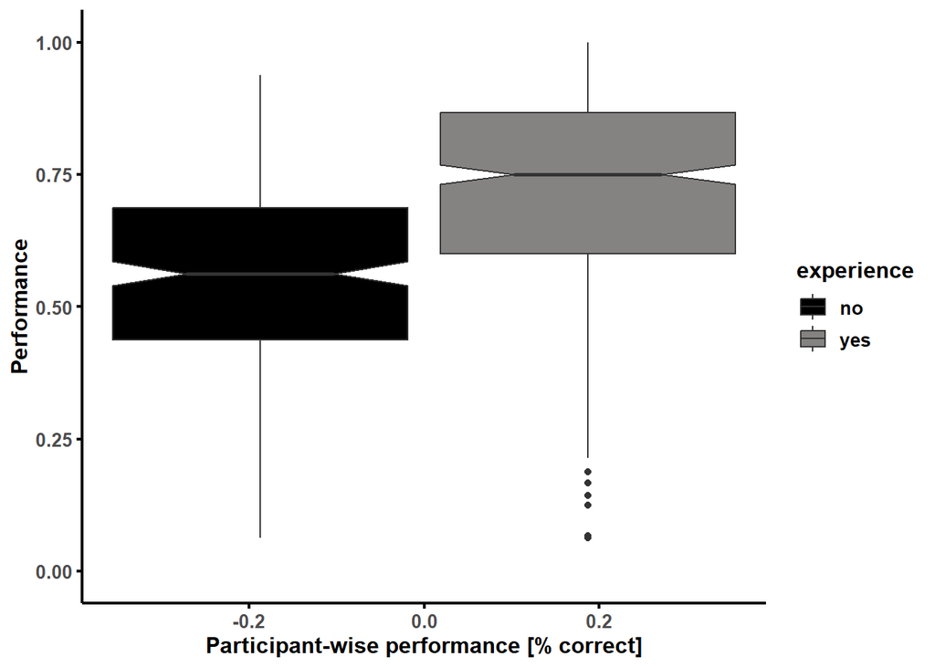

```r
ggplot(participant_data, aes(fill=experience, y=mean_response)) +
  geom_boxplot(notch = TRUE) +
  plot_theme +
  xlab("Participant-wise performance [% correct]") +
  scale_fill_manual(values=c("black", "#858382")) +
  ylab("Performance") +
  ylim(-0.01, 1.01)
```

### 4.5.4. Statistical comparison

##### Anderson-Darling test for normality

```r
ad.test(participant_data$mean_response)
```

```
##
##  Anderson-Darling normality test
##
## data:  participant_data$mean_response
## A = 9.671, p-value < 2.2e-16
```

```r
ad.test(participant_data$mean_response[participant_data$experience=="yes"])
```

```
##
##  Anderson-Darling normality test
##
## data:  participant_data$mean_response[participant_data$experience ==     "yes"]
## A = 9.0113, p-value < 2.2e-16
```

```r
ad.test(participant_data$mean_response[participant_data$experience=="no"])
```

```
##
##  Anderson-Darling normality test
##
## data:  participant_data$mean_response[participant_data$experience ==     "no"]
## A = 2.0797, p-value = 2.672e-05
```

RESULTS: The distribution of the data differs highly significantly from a normal distribution.

##### Inferential statistics: Wilcoxon rank sum test

```r
med_perf_e <- median(participant_data$mean_response[participant_data$experience == "yes"])
med_perf_n <- median(participant_data$mean_response[participant_data$experience == "no"])
c(med_perf_e, med_perf_n)
```

```
## [1] 0.7500 0.5625
```

```r
wilcox.test(participant_data$mean_response[participant_data$experience == "yes"],
            participant_data$mean_response[participant_data$experience == "no"], paired=FALSE)
```

```
##
##  Wilcoxon rank sum test with continuity correction
##
## data:  participant_data$mean_response[participant_data$experience == "yes"] and participant_data$mean_response[participant_data$experience == "no"]
## W = 106880, p-value < 2.2e-16
## alternative hypothesis: true location shift is not equal to 0
```

RESULTS: Participant-wise performance differs statistically significantly between naive and expert participants.

# 5. Analysis of response times

## 5.1. Remove images without response

as there is no associated response time to work with

```r
nrow(imageClassificationDataLong)
```

```
## [1] 13056
```

```r
imageClassificationDataLong_2 <- imageClassificationDataLong %>% drop_na(time)
nrow(imageClassificationDataLong_2)
```

```
## [1] 12838
```

## 5.2. Sanity checks

### 5.2.1. Check effect of presentation order on response time

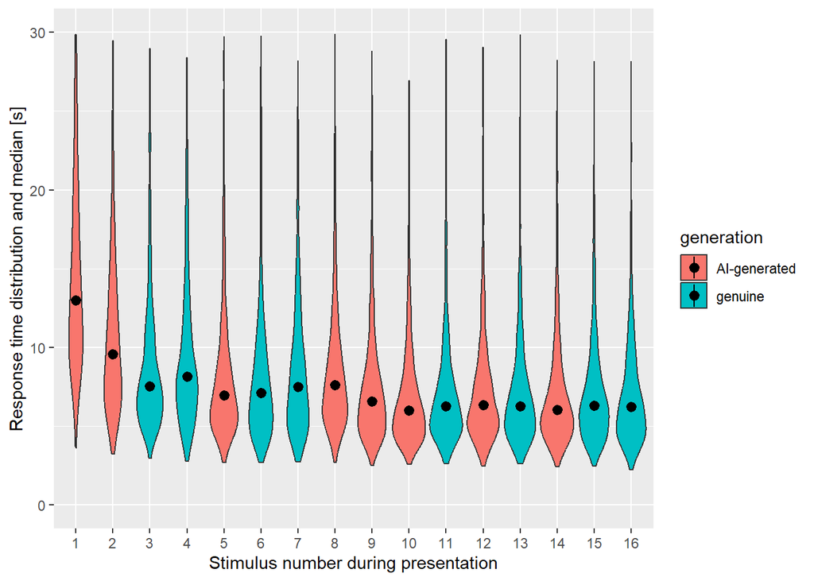

```r
bp_order_time <- ggplot(imageClassificationDataLong_2, aes(y=time, x=as.factor(stimNo), fill=generation)) +
  geom_violin() +
  stat_summary(fun="median") +
  ylim(0,30) +
  xlab("Stimulus number during presentation") +
  ylab("Response time distribution and median [s]")

bp_order_time
```

INTERPRETATION: There is a clear, effect of stimulus presentation order on response times. This results in a higher response time in particular for the first two images presented, which are both artificial images. Thus do not include image category as an factor for analysis of response times.

NOTE: The 371 dropped values in this in subsequent plots are those response times > 30s, which do not get plotted due to the imposed axis limit:

```r
sum(imageClassificationDataLong_2$time>30)
```

```
## [1] 371
```

However, these ‘outliers’ are still included in all statistical analyses.

### 5.2.2. Effect of presentation order on classification correctness

##### Overview

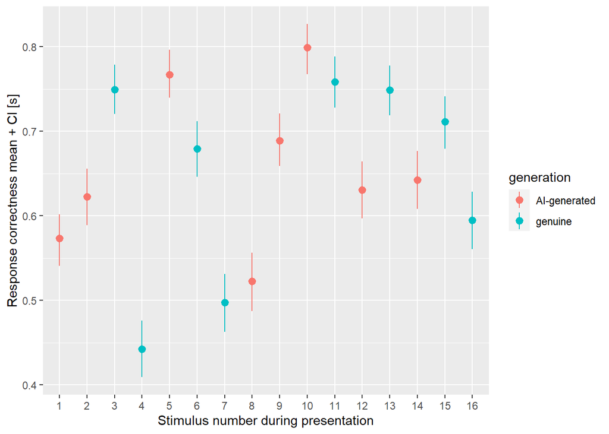

```r
bp_order_response <- ggplot(imageClassificationDataLong_2, aes(y=response_i, x=as.factor(stimNo), color=generation)) +
  stat_summary(fun.data = "mean_cl_boot") +
  xlab("Stimulus number during presentation") +
  ylab("Response correctness mean + CI [s]")

bp_order_response
```

##### Correlation

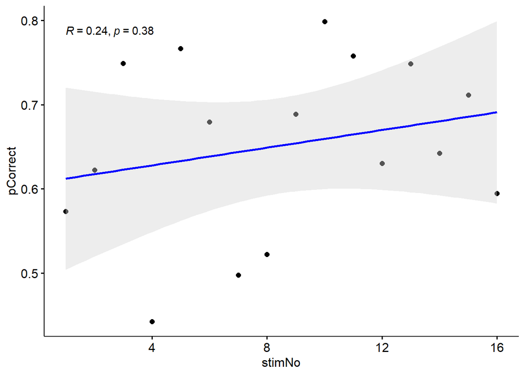

```r
dataCastByStimNo <- dcast(imageClassificationDataLong_2, stimNo ~ response, length)

dataCastByStimNo$pCorrect <- dataCastByStimNo$correct / (dataCastByStimNo$correct + dataCastByStimNo$incorrect)

ggscatter(dataCastByStimNo, x = "stimNo", y = "pCorrect",
          add = "reg.line", conf.int = TRUE,
          add.params = list(color = "blue", fill = "lightgray"))+
  stat_cor(method = "pearson")
```

```r
# Note: if calculated separately by participant group the conclusion holds true as well:
# Naives: R = 0.28, p = 0.29
# Experts: R = 0.21, p = 0.43
# dataCastByStimNo <- dcast(imageClassificationDataLong_2,
#                           stimNo ~ response + Image_seen_before,
#                           length)
```

INTERPRETATION: There is no relevant effect of stimulus presentation order on classification correctness.

## 5.3. Statistical analysis of effects on response times

### 5.3.1. Anderson-Darling test for normality

```r
ad.test(imageClassificationDataLong_2$time)
```

```
##
##  Anderson-Darling normality test
##
## data:  imageClassificationDataLong_2$time
## A = 3427.6, p-value < 2.2e-16
```

The data are non-normally distributed. The same is true when testing for distribution of subpopulations (see below.) Thus use the Scheirer-Ray-Hare test as non-parametric alternative to an ANOVA.

### 5.3.2. Further considerations

- Age is different between experienced and controls, thus not independent of prior experience
- Gender composition is different between experienced and controls, thus not independent of prior experience
- The effect of image category depends on the stimulus presentation order

CONCLUSION: Only analyse effect of prior experience and response correctness on response time.

### 5.3.3. Scheirer-Ray-Hare test

as non-parametric alternative to ANOVA

```r
lm <- scheirerRayHare(time ~ Image_seen_before*response, data=imageClassificationDataLong_2)
```

```
##
## DV:  time
## Observations:  12838
## D:  0.9999988
## MS total:  13735590
```

```r
lm
```

```
##                               Df     Sum Sq      H  p.value
## Image_seen_before              1 7.0557e+08 51.368 0.000000
## response                       1 1.0838e+09 78.906 0.000000
## Image_seen_before:response     1 8.4459e+07  6.149 0.013149
## Residuals                  12834 1.7467e+11
```

```r
summary(lm)
```

```
##        Df            Sum Sq                H             p.value
##  Min.   :    1   Min.   :8.446e+07   Min.   : 6.149   Min.   :0.000000
##  1st Qu.:    1   1st Qu.:5.503e+08   1st Qu.:28.759   1st Qu.:0.000000
##  Median :    1   Median :8.947e+08   Median :51.368   Median :0.000000
##  Mean   : 3209   Mean   :4.414e+10   Mean   :45.474   Mean   :0.004383
##  3rd Qu.: 3209   3rd Qu.:4.448e+10   3rd Qu.:65.137   3rd Qu.:0.006574
##  Max.   :12834   Max.   :1.747e+11   Max.   :78.906   Max.   :0.013149
##                                      NA's   :1        NA's   :1
```

### 5.3.4. Pair-wise post hoc comparisons

#### 5.3.4.1. Effect of classification correctness

##### Plot CDF: Full response times

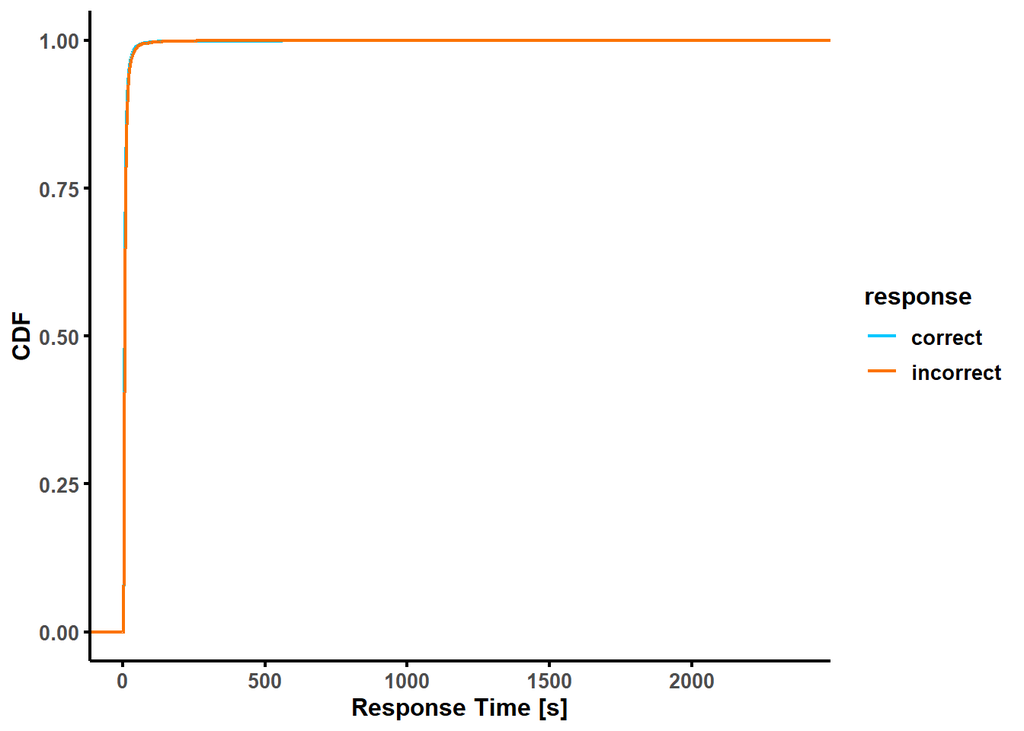

```r
ggplot(imageClassificationDataLong_2, aes(color=response, x=time)) +
  stat_ecdf(size=.75) +
  xlab("Response Time [s]") +
  ylab("CDF") +
  scale_color_manual(values = c("#03c7ff", "#fc7303")) +
  plot_theme
```

INTERPRETATION: Very long tail - very likely cases in which participants just left browser window open, did something else and returned to study at at some later point.

##### Plot CDF: First 30 seconds

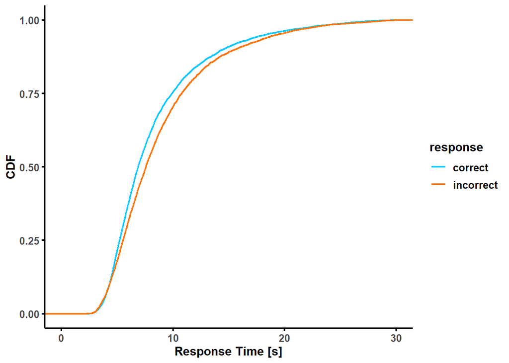

```r
ggplot(imageClassificationDataLong_2, aes(color=response, x=time)) +
  stat_ecdf(size=.75) +
  xlim(0,30) +
  xlab("Response Time [s]") +
  ylab("CDF") +
  scale_color_manual(values = c("#03c7ff", "#fc7303")) +
  plot_theme
```

##### Anderson-Darling test for normality

```r
ad.test(imageClassificationDataLong_2$time[imageClassificationDataLong_2$response=="correct"])
```

```
##
##  Anderson-Darling normality test
##
## data:  imageClassificationDataLong_2$time[imageClassificationDataLong_2$response ==     "correct"]
## A = 2386, p-value < 2.2e-16
```

```r
ad.test(imageClassificationDataLong_2$time[imageClassificationDataLong_2$response=="incorrect"])
```

```
##
##  Anderson-Darling normality test
##
## data:  imageClassificationDataLong_2$time[imageClassificationDataLong_2$response ==     "incorrect"]
## A = 830.65, p-value < 2.2e-16
```

RESULTS: The distribution of the data differs significantly from a normal distribution.

##### Wilcoxon rank sum test

```r
wilcox.test(imageClassificationDataLong_2$time[imageClassificationDataLong_2$response=="correct"],
       imageClassificationDataLong_2$time[imageClassificationDataLong_2$response=="incorrect"], paired=FALSE)
```

```
##
##  Wilcoxon rank sum test with continuity correction
##
## data:  imageClassificationDataLong_2$time[imageClassificationDataLong_2$response == "correct"] and imageClassificationDataLong_2$time[imageClassificationDataLong_2$response == "incorrect"]
## W = 17121526, p-value = 2.021e-15
## alternative hypothesis: true location shift is not equal to 0
```

##### Median response time difference

```r
m_c <- median(imageClassificationDataLong_2$time[imageClassificationDataLong_2$response=="correct"])
m_i <- median(imageClassificationDataLong_2$time[imageClassificationDataLong_2$response=="incorrect"])
c(m_c, m_i)
```

```
## [1] 6.99 7.70
```

#### 5.3.4.2. Effect of prior experience

##### Plot CDF: Full response times

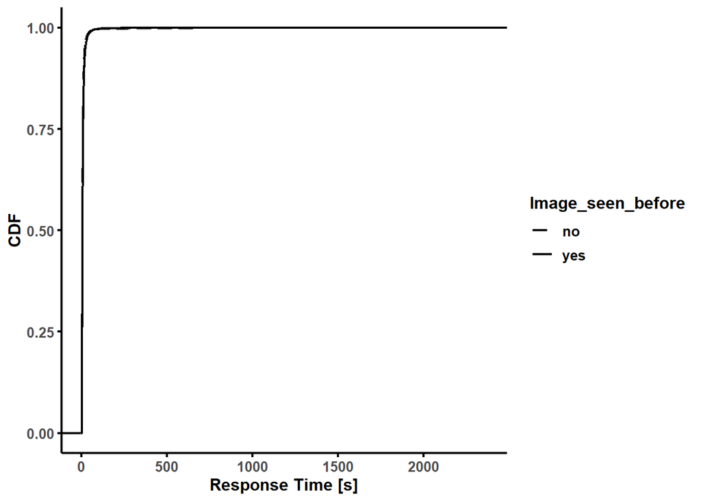

```r
ggplot(imageClassificationDataLong_2, aes(linetype=Image_seen_before, x=time)) +
  stat_ecdf(size=.75) +
  xlab("Response Time [s]") +
  ylab("CDF") +
  scale_linetype_manual(values=c("longdash", "solid"))+
  plot_theme
```

##### Plot CDF: First 30 seconds

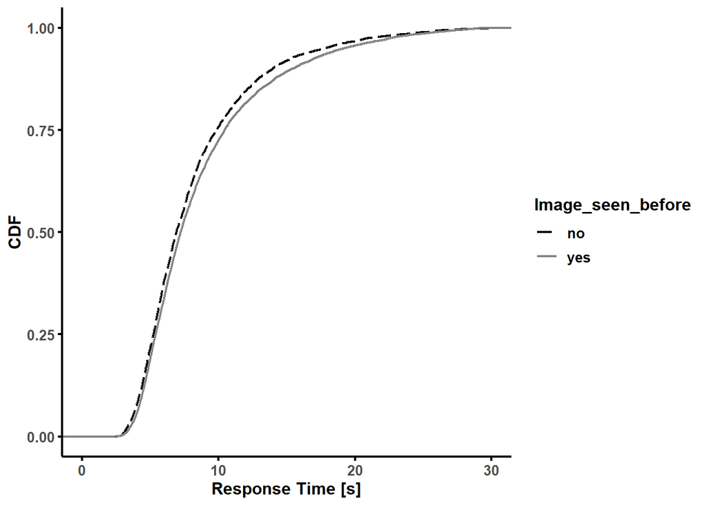

```r
ggplot(imageClassificationDataLong_2, aes(linetype=Image_seen_before, x=time, color=Image_seen_before)) +
  stat_ecdf(size=.75) +
  xlim(0,30) +
  xlab("Response Time [s]") +
  ylab("CDF") +
  scale_linetype_manual(values=c("longdash", "solid"))+
  scale_color_manual(values=c("black", "#858382")) +
  plot_theme
```

##### Anderson-Darling test for normality

```r
ad.test(imageClassificationDataLong_2$time[imageClassificationDataLong_2$Image_seen_before=="yes"])
```

```
##
##  Anderson-Darling normality test
##
## data:  imageClassificationDataLong_2$time[imageClassificationDataLong_2$Image_seen_before ==     "yes"]
## A = 2016.5, p-value < 2.2e-16
```

```r
ad.test(imageClassificationDataLong_2$time[imageClassificationDataLong_2$Image_seen_before=="no"])
```

```
##
##  Anderson-Darling normality test
##
## data:  imageClassificationDataLong_2$time[imageClassificationDataLong_2$Image_seen_before ==     "no"]
## A = 1335.9, p-value < 2.2e-16
```

RESULTS: The distribution of the data differs significantly from a normal distribution.

##### Wilcoxon rank sum test

```r
wilcox.test(imageClassificationDataLong_2$time[imageClassificationDataLong_2$Image_seen_before=="yes"],
            imageClassificationDataLong_2$time[imageClassificationDataLong_2$Image_seen_before=="no"], paired=FALSE)
```

```
##
##  Wilcoxon rank sum test with continuity correction
##
## data:  imageClassificationDataLong_2$time[imageClassificationDataLong_2$Image_seen_before == "yes"] and imageClassificationDataLong_2$time[imageClassificationDataLong_2$Image_seen_before == "no"]
## W = 20005531, p-value = 2.542e-09
## alternative hypothesis: true location shift is not equal to 0
```

##### Median response time difference

```r
m_e <-median (imageClassificationDataLong_2$time[imageClassificationDataLong_2$Image_seen_before=="yes"])
m_n <- median(imageClassificationDataLong_2$time[imageClassificationDataLong_2$Image_seen_before=="no"])
c(m_n, m_e)
```

```
## [1] 6.98 7.35
```

#### 5.3.4.3. Combined effect: Prior experience <> classification correctness

##### Format data

```r
imageClassificationDataLong_2 <- imageClassificationDataLong_2 %>%
  mutate(
    plotGroup = case_when(
      response == "correct" & Image_seen_before == "no" ~ "naive, correct answer",
      response == "incorrect" & Image_seen_before == "no" ~ "naive, incorrect answer",
      response == "correct" & Image_seen_before == "yes" ~ "expert, correct answer",
      response == "incorrect" & Image_seen_before == "yes" ~ "expert, incorrect answer",
    )
  )
```

##### Plot CDF: First 30 seconds

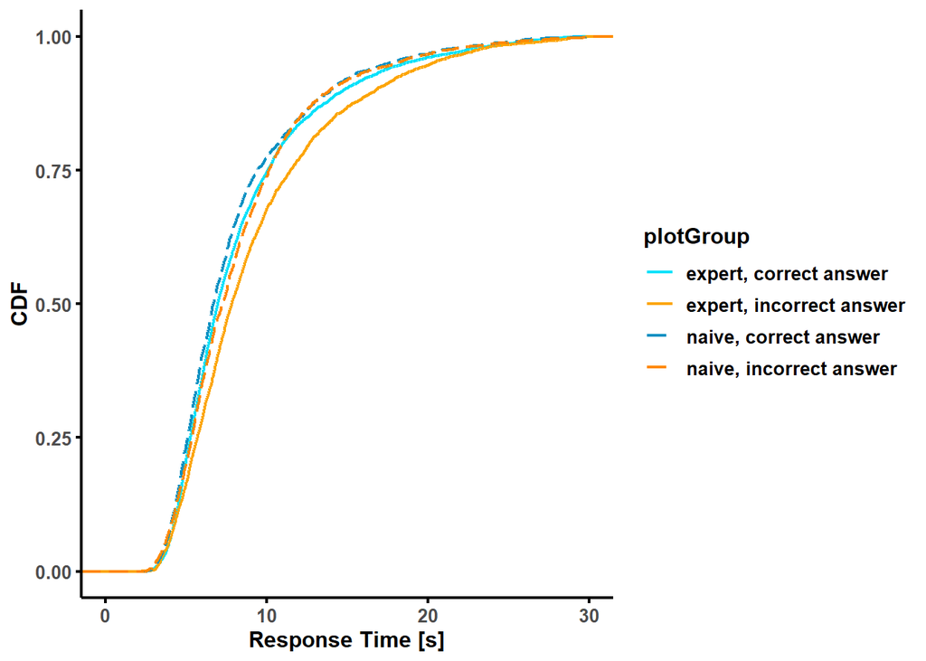

```r
ggplot(imageClassificationDataLong_2, aes(color=plotGroup, x=time)) +
  stat_ecdf(size=.75, aes(linetype = plotGroup)) +
  xlim(0,30)+
  xlab("Response Time [s]") +
  ylab("CDF") +
  scale_color_manual(values = c("#02e1fa", "#fca503","#0690c2", "#ff8800")) +
  scale_linetype_manual(values=c("solid", "solid", "longdash", "longdash"))+
  plot_theme
```

##### Wilcoxon rank sum test with Bonferroni correction

```r
# data
group1 <- imageClassificationDataLong_2$time[imageClassificationDataLong_2$plotGroup == "naive, correct answer"]
group2 <- imageClassificationDataLong_2$time[imageClassificationDataLong_2$plotGroup == "naive, incorrect answer"]
group3 <- imageClassificationDataLong_2$time[imageClassificationDataLong_2$plotGroup == "expert, correct answer"]
group4 <- imageClassificationDataLong_2$time[imageClassificationDataLong_2$plotGroup == "expert, incorrect answer"]

# un-paired t-test
p1 <- wilcox.test(group1, group2, paired=FALSE)
p2 <- wilcox.test(group1, group3, paired=FALSE)
p3 <- wilcox.test(group1, group4, paired=FALSE)
p4 <- wilcox.test(group2, group3, paired=FALSE)
p5 <- wilcox.test(group2, group4, paired=FALSE)
p6 <- wilcox.test(group3, group4, paired=FALSE)

# bonferroni
p_vals <- c(p1$p.value, p2$p.value, p3$p.value, p4$p.value, p5$p.value, p6$p.value)
p_adj <- p_vals * length(p_vals)
p_adj[p_adj > 1] <- 1
p_adj
```

```
## [1] 1.517383e-03 2.332722e-04 3.610056e-25 1.000000e+00 5.003647e-10 1.227466e-16
```

##### Median response time difference

```r
# data
m1 <- median(imageClassificationDataLong_2$time[imageClassificationDataLong_2$plotGroup == "naive, correct answer"])
m2 <- median(imageClassificationDataLong_2$time[imageClassificationDataLong_2$plotGroup == "naive, incorrect answer"])
m3 <- median(imageClassificationDataLong_2$time[imageClassificationDataLong_2$plotGroup == "expert, correct answer"])
m4 <- median(imageClassificationDataLong_2$time[imageClassificationDataLong_2$plotGroup == "expert, incorrect answer"])

median_times <- c(m1, m2, m3, m4)
median_times
```

```
## [1] 6.77 7.38 7.07 8.06
```

#### 5.3.4.4. Within-participant pair-wise response time comparison

##### Format data

Within-participant pair wise comparison of average response times for correct and incorrect classifications in order to control for the possibility that people who are less well able to distinguish between image categories are slower.

```r
# preallocate
pairwise_data_length <- length(unique(imageClassificationDataLong_2$ID)) *
                     length(unique(imageClassificationDataLong_2$response))
pairwise_data <- data.frame(no=rep(NA,pairwise_data_length),
                          id=rep(NA,pairwise_data_length),
                          experience=rep(NA,pairwise_data_length),
                          response=rep(NA,pairwise_data_length),
                          time_mean=rep(NA,pairwise_data_length))


counter = 1
for(x in unique(imageClassificationDataLong_2$ID)){
    for(y in unique(imageClassificationDataLong_2$response)){
      tmp_data <- imageClassificationDataLong_2 %>% subset(ID == x & response == y)
      pairwise_data$no[counter] <- counter
      pairwise_data$id[counter] <- tmp_data$ID[1]
      pairwise_data$experience[counter] <- tmp_data$Image_seen_before[1]
      pairwise_data$response[counter] <- tmp_data$response[1]
      pairwise_data$time_mean[counter] <- tmp_data$time %>% mean
      counter = counter + 1
  }
}
```

Find non-paired mean values

```r
# missing mean times
na_ind <- which(is.na(pairwise_data$time_mean))

# add odd inds for even ones & vice versa
na_ind_addOdd <- na_ind[which(na_ind %% 2 == 0)] - 1
na_ind_addEven <- na_ind[which(na_ind %% 2 != 0)] + 1
na_ind_all <- c(na_ind, na_ind_addOdd, na_ind_addEven)
na_ind_all <- sort(setdiff(na_ind_all, na_ind_all[duplicated(na_ind_all)]))   # unique IDs after exclusion

# non-paired vs. paired data
nonpaired_data <- pairwise_data[na_ind_all,] # correct answers only
paired_data <- pairwise_data[-na_ind_all,]   # correct and incorrect answers
```

Participants excluded from pairwise comparison due to all responses correct

```r
# entry #s
na_ind_all
```

```
##  [1]   83   84  131  132  415  416  481  482  487  488  541  542  567  568  643  644  739  740 1545 1546
```

```r
# n participant (2 entries / participant)
length(na_ind_all)/2
```

```
## [1] 10
```

```r
# by experience
tbl_all_corrrect <- table(nonpaired_data$experience[nonpaired_data$response=="correct"])
tbl_all_corrrect
```

```
##
## yes
##  10
```

NOTE: There are no naive participants who classify all images correctly.

##### Excursion: Enrichment statistics of experts classifying all images correctly (exact binomial test)

```r
# average chance of success for experts
p_expert <- mean(imageClassificationDataLong_2$response_i[imageClassificationDataLong_2$Image_seen_before=="yes"])

# probability to get all 16 images correct assuming average expert success rate
prob_all_correct <- p_expert^16

# number of experts with 16 (=100%) successes
e_all_correct <- tbl_all_corrrect[1]

# binomial test
binom.test(e_all_correct,
           n_expert,
           p=prob_all_correct)
```

```
##
##  Exact binomial test
##
## data:  e_all_correct and n_expert
## number of successes = 10, number of trials = 526, p-value = 2.004e-05
## alternative hypothesis: true probability of success is not equal to 0.003459259
## 95 percent confidence interval:
##  0.009153426 0.034684063
## sample estimates:
## probability of success
##             0.01901141
```

```r
# enrichment ratio
ExpectVal <- prob_all_correct * n_expert
ER <- 10/ExpectVal
ER
```

```
## [1] 5.495803
```

A total of 10 (expert) participants answered all questions correctly. This performance is way above chance.

##### Plot CDF: First 30 seconds

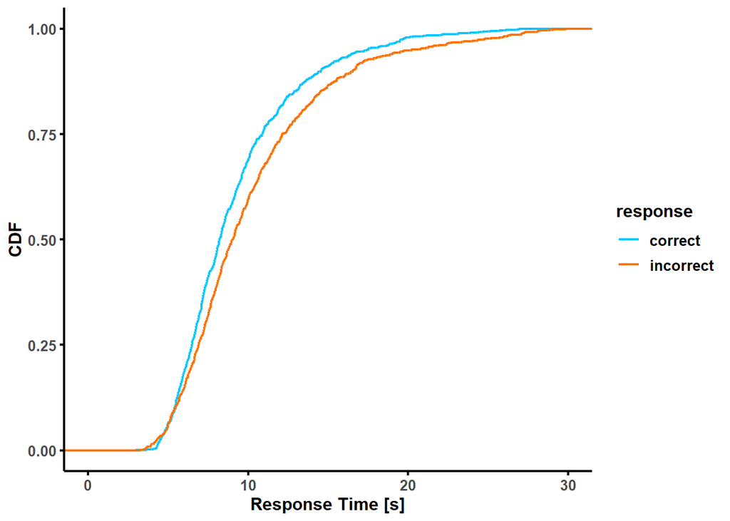

```r
ggplot(paired_data, aes(x=time_mean, color=response)) +
  stat_ecdf(size=0.75)  +
  xlab("Response Time [s]") +
  ylab("CDF") +
  scale_color_manual(values = c("#03c7ff", "#fc7303")) +
  plot_theme +
  xlim(0,30)
```

##### Plot boxplot: First 30 seconds

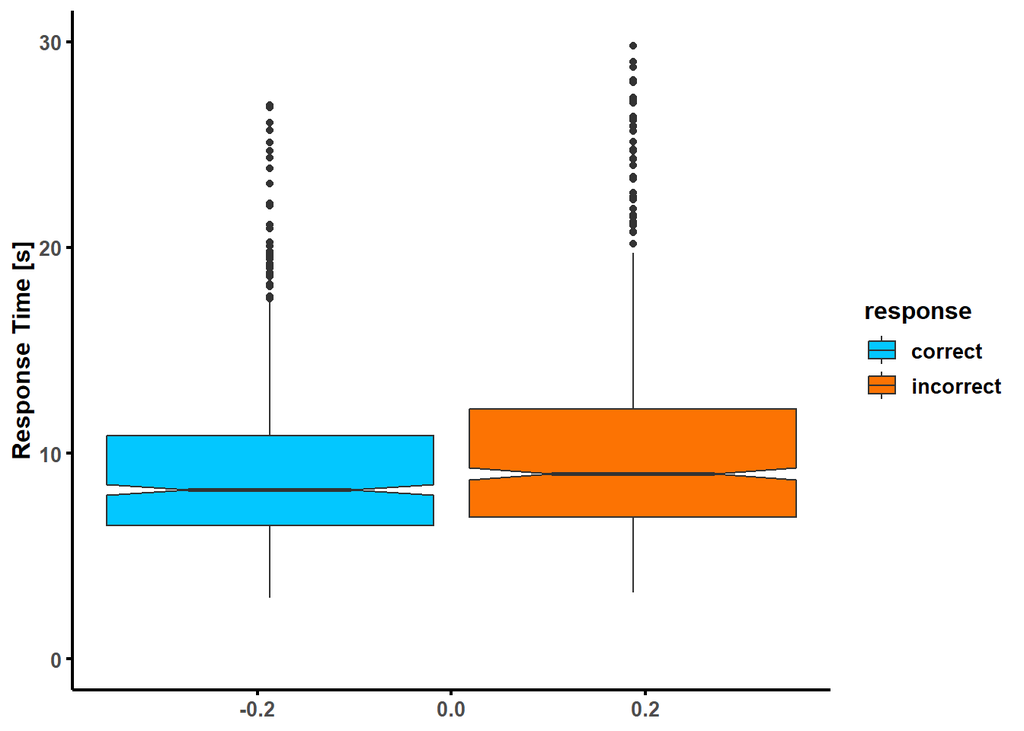

```r
ggplot(paired_data, aes(y=time_mean, fill=response)) +
  geom_boxplot(notch=TRUE)  +
  ylab("Response Time [s]") +
  scale_fill_manual(values = c("#03c7ff", "#fc7303")) +
  plot_theme +
  ylim(0,30)
```

##### Anderson-Darling test for normality

```r
ad.test(paired_data$time_mean)
```

```
##
##  Anderson-Darling normality test
##
## data:  paired_data$time_mean
## A = 295.69, p-value < 2.2e-16
```

```r
ad.test(paired_data$time_mean[paired_data$response == "correct"])
```

```
##
##  Anderson-Darling normality test
##
## data:  paired_data$time_mean[paired_data$response == "correct"]
## A = 183.35, p-value < 2.2e-16
```

```r
ad.test(paired_data$time_mean[paired_data$response == "incorrect"])
```

```
##
##  Anderson-Darling normality test
##
## data:  paired_data$time_mean[paired_data$response == "incorrect"]
## A = 85.944, p-value < 2.2e-16
```

##### Wilcoxon singed rank test

```r
wilcox.test(paired_data$time_mean[paired_data$response == "correct"],
            paired_data$time_mean[paired_data$response == "incorrect"], paired=TRUE)
```

```
##
##  Wilcoxon signed rank test with continuity correction
##
## data:  paired_data$time_mean[paired_data$response == "correct"] and paired_data$time_mean[paired_data$response == "incorrect"]
## V = 123754, p-value = 1.027e-08
## alternative hypothesis: true location shift is not equal to 0
```

##### Median response time difference

```r
m_c_p <- median(paired_data$time_mean[paired_data$response == "correct"])
m_i_p <- median(paired_data$time_mean[paired_data$response == "incorrect"])
c(m_c_p, m_i_p)
```

```
## [1] 8.326000 9.166667
```